# School Revenue Data Science Project

Brenndan Olson

Public school’s rely heavily on their budgets to give students access to the best learning experience possible.For this project I am going to investigate public school district finance data and determine any factors that contribute to how good a district is.

This is a dataset from the United States Census Bureau on financial data of public school districts in 2017. Upon investigating the documentation, I saw that this one dataset contains all of the different financial aspects including total revenue, total spending, and expenditure on staff and administration. The data should be fairly accurate with little to no bias, because school budgets are publically available, and the data was collected by the government.

## Importing Data

Loading in the necessary libraries and data file, then naming it finance_data. “includes.R” is a R script I created that will install any missing libraries and load them.

```r
source("includes.R")
finance_data <- read.csv("elsec17.csv")
head(finance_data)
```

```
##   STATE   IDCENSUS                           NAME CONUM CSA  CBSA SCHLEV
## 1     1 1.5001e+12 AUTAUGA COUNTY SCHOOL DISTRICT  1001   N 33860     03
## 2     1 1.5002e+12 BALDWIN COUNTY SCHOOL DISTRICT  1003 380 19300     03
## 3     1 1.5003e+12 BARBOUR COUNTY SCHOOL DISTRICT  1005   N 21640     03
## 4     1 1.5003e+12   EUFAULA CITY SCHOOL DISTRICT  1005   N 21640     03
## 5     1 1.5004e+12    BIBB COUNTY SCHOOL DISTRICT  1007 142 13820     03
## 6     1 1.5005e+12  BLOUNT COUNTY SCHOOL DISTRICT  1009 142 13820     03
##    NCESID YRDATA   V33 TOTALREV TFEDREV  C14  C15 C16 C17 C19 B11  C20
## 1 0100240     17  9307    82619    7167 1778 1936 314   0 154  30  150
## 2 0100270     17 31268   363148   24673 6769 6287 947   0 366 173 1732
## 3 0100300     17   847    10628    2140 1057  268 122   0  31   0   25
## 4 0101410     17  3949    28397    3487  965  600 134   0  41  18  318
## 5 0100360     17  3291    33469    3596  995  882 186   0  46   0  178
## 6 0100420     17  7793    76256    7297 2453 1646 334   0 129  51   57
##    C25 C36 B10 B12 B13 TSTREV    C01 C04 C05  C06 C07 C08 C09 C10  C11
```

[output cut: 62 more lines]

The dataset is too big to be outputted neatly, so let’s see how many rows and columns are in this dataset:

```r
nrow(finance_data)
```

```
## [1] 14306
```

```r
ncol(finance_data)
```

```
## [1] 141
```

141 columns is quite a lot, so for now I am just going to focus on the total revenue from state taxes. There is other financial data including some federal and misc. variables, but most of them are vague and not super clear what they are. Working with just state data for now will keep things simple.

## Cleaning and tidying data

Here are all of the current column’s names related to state revenue:

```r
colnames(finance_data)[c(1:10,25:40)]
```

```
##  [1] "STATE"    "IDCENSUS" "NAME"     "CONUM"    "CSA"      "CBSA"
##  [7] "SCHLEV"   "NCESID"   "YRDATA"   "V33"      "TSTREV"   "C01"
## [13] "C04"      "C05"      "C06"      "C07"      "C08"      "C09"
## [19] "C10"      "C11"      "C12"      "C13"      "C24"      "C35"
## [25] "C38"      "C39"
```

Here is what each column represents:  
STATE: State id number  
IDCENSUS: School district id number  
NAME: School district name  
CONUM: ANSI state and county code, used for geographic information  
CSA: Consolidated statistical area,  
CBSA: Core-based statistical area,  
SCHLEV: School level code,  
NCESID: NCESID code,  
YRDATA: year of data gathered  
V33: Fall membership, meaning total number of students attending at start of fall semester/trimester  
TSTREV: Total state revenue for each district, a combination of the next 15 rows  
C01: General formula assistance,  
C04: Staff improvement programs  
C05: Special education programs  
C06: Compensatory and basic skills attainment programs  
C07: Billingual education programs  
C08: Gifted and talented programs  
C09: Vocational education programs  
C10: School lunch programs  
C11: Capital outlay and debt service programs  
C12: Transportation programs  
C13: Other state revenue sources  
C24: NCES local revenue  
C35: State revenue - nonspecified  
C38: State payments - benefits  
C39: State payments - nonbenefits

For all the monetary values, they are represented in thousands of dollars.

Now it is time to start making the data more readable, starting with changing the column names to something more recognizable and easier to infer what that column represents:

```r
colnames(finance_data)[colnames(finance_data) == "STATE"] <- "state"
colnames(finance_data)[colnames(finance_data) == "IDCENSUS"] <- "id_number"
colnames(finance_data)[colnames(finance_data) == "NAME"] <- "school_district"
colnames(finance_data)[colnames(finance_data) == "CONUM"] <- "ansi_code"
colnames(finance_data)[colnames(finance_data) == "CSA"] <- "consolidated_statistical_area"
colnames(finance_data)[colnames(finance_data) == "CBSA"] <- "core_based_statistical_area"
colnames(finance_data)[colnames(finance_data) == "SCHLEV"] <- "school_level"
colnames(finance_data)[colnames(finance_data) == "NCESID"] <- "nces_id"
colnames(finance_data)[colnames(finance_data) == "YRDATA"] <- "year"
colnames(finance_data)[colnames(finance_data) == "V33"] <- "fall_attendance"
colnames(finance_data)[colnames(finance_data) == "TSTREV"] <- "total_state_revenue"
colnames(finance_data)[colnames(finance_data) == "C01"] <- "general_formula_assistance"
colnames(finance_data)[colnames(finance_data) == "C04"] <- "staff_improvement_programs"
colnames(finance_data)[colnames(finance_data) == "C05"] <- "special_education_programs"
colnames(finance_data)[colnames(finance_data) == "C06"] <- "compensatory_and_basic_skills"
colnames(finance_data)[colnames(finance_data) == "C07"] <- "billingual_education"
colnames(finance_data)[colnames(finance_data) == "C08"] <- "gifted_and_talented"
colnames(finance_data)[colnames(finance_data) == "C09"] <- "vocational_education"
colnames(finance_data)[colnames(finance_data) == "C10"] <- "school_lunch"
colnames(finance_data)[colnames(finance_data) == "C11"] <- "capital_outlay_and_debt_service"
colnames(finance_data)[colnames(finance_data) == "C12"] <- "transportation"
colnames(finance_data)[colnames(finance_data) == "C13"] <- "other_state_revenue"
colnames(finance_data)[colnames(finance_data) == "C24"] <- "nces_local_revenue"
colnames(finance_data)[colnames(finance_data) == "C35"] <- "nonspecified_state_revenue"
colnames(finance_data)[colnames(finance_data) == "C38"] <- "state_payments_benefits"
colnames(finance_data)[colnames(finance_data) == "C39"] <- "state_payments_nonbenefits"
colnames(finance_data)[c(1:10,25:40)]
```

```
##  [1] "state"                           "id_number"
##  [3] "school_district"                 "ansi_code"
##  [5] "consolidated_statistical_area"   "core_based_statistical_area"
##  [7] "school_level"                    "nces_id"
##  [9] "year"                            "fall_attendance"
## [11] "total_state_revenue"             "general_formula_assistance"
## [13] "staff_improvement_programs"      "special_education_programs"
## [15] "compensatory_and_basic_skills"   "billingual_education"
## [17] "gifted_and_talented"             "vocational_education"
## [19] "school_lunch"                    "capital_outlay_and_debt_service"
## [21] "transportation"                  "other_state_revenue"
## [23] "nces_local_revenue"              "nonspecified_state_revenue"
## [25] "state_payments_benefits"         "state_payments_nonbenefits"
```

Since some of this information is about the school districts and the rest is on state revenue, It makes sense to split these into two different tables, school_districts and state_revenue. School_districts will contain the general information on each school district, and state_revenue contains each school district’s state revenue and spending.

```r
school_districts <- dplyr::tibble(
 state = finance_data$state,
 id_number = finance_data$id_number,
 school_district = as.character(finance_data$school_district),
 ANSI_code = finance_data$ansi_code,
 consolidated_statistical_area = finance_data$consolidated_statistical_area,
 core_based_statistical_area = finance_data$core_based_statistical_area,
 school_level = as.character(finance_data$school_level),
 nces_id = finance_data$nces_id,
 fall_attendance = finance_data$fall_attendance
 )
state_revenue <- dplyr::tibble(
 state = finance_data$state,
 school_district = as.character(finance_data$school_district),
 fall_attendance = finance_data$fall_attendance,
 general_formula_assistance = finance_data$general_formula_assistance,
 staff_improvement_programs = finance_data$staff_improvement_programs,
 special_education_programs = finance_data$special_education_programs,
 compensatory_and_basic_skills = finance_data$compensatory_and_basic_skills,
 billingual_education = finance_data$billingual_education,
 gifted_and_talented = finance_data$gifted_and_talented,
 vocational_education = finance_data$vocational_education,
 school_lunch = finance_data$school_lunch,
 capital_outlay_and_debt_service = finance_data$capital_outlay_and_debt_service,
 transportation = finance_data$transportation,
 other_state_revenue = finance_data$other_state_revenue,
 nces_local_revenue = finance_data$nces_local_revenue,
 nonspecified_state_revenue = finance_data$nonspecified_state_revenue,
 state_payments_benefits = finance_data$state_payments_benefits,
 state_payments_nonbenefits = finance_data$state_payments_nonbenefits,
 total_state_revenue = finance_data$total_state_revenue
)
```

Now let’s see what the two new tables look like:

```r
head(school_districts)
```

```
## # A tibble: 6 x 9
##   state id_number school_district ANSI_code consolidated_st…
##   <int>     <dbl> <chr>               <int> <fct>
## 1     1   1.50e12 AUTAUGA COUNTY…      1001 N
## 2     1   1.50e12 BALDWIN COUNTY…      1003 380
## 3     1   1.50e12 BARBOUR COUNTY…      1005 N
## 4     1   1.50e12 EUFAULA CITY S…      1005 N
## 5     1   1.50e12 BIBB COUNTY SC…      1007 142
## 6     1   1.50e12 BLOUNT COUNTY …      1009 142
## # … with 4 more variables: core_based_statistical_area <fct>,
## #   school_level <chr>, nces_id <fct>, fall_attendance <int>
```

```r
head(state_revenue)
```

```
## # A tibble: 6 x 19
##   state school_district fall_attendance general_formula… staff_improveme…
##   <int> <chr>                     <int>            <int>            <int>
## 1     1 AUTAUGA COUNTY…            9307            47256               65
## 2     1 BALDWIN COUNTY…           31268           133128              101
## 3     1 BARBOUR COUNTY…             847             4124               40
## 4     1 EUFAULA CITY S…            3949            15639               61
## 5     1 BIBB COUNTY SC…            3291            18375               57
## 6     1 BLOUNT COUNTY …            7793            42013               49
## # … with 14 more variables: special_education_programs <int>,
## #   compensatory_and_basic_skills <int>, billingual_education <int>,
## #   gifted_and_talented <int>, vocational_education <int>,
## #   school_lunch <int>, capital_outlay_and_debt_service <int>,
## #   transportation <int>, other_state_revenue <int>,
## #   nces_local_revenue <int>, nonspecified_state_revenue <int>,
## #   state_payments_benefits <int>, state_payments_nonbenefits <int>,
## #   total_state_revenue <int>
```

We are getting closer to having clean data, but there are still a few things that need to be done. First I am going to start with the school_districts.

### Cleaning school_districts

```r
school_districts$state[school_districts$state == 9] <- ("District of Columbia")
for(i in 1:8) {
  school_districts$state[school_districts$state == i] <- (state.name[i])
}
for(i in 10:51) {
  school_districts$state[school_districts$state == i] <- (state.name[i-1])
}
head(school_districts$state)
```

```
## [1] "Alabama" "Alabama" "Alabama" "Alabama" "Alabama" "Alabama"
```

Doing the same for school_level is also a good idea, to help make it easier to read:

```r
school_districts$school_level[school_districts$school_level == "01"] <- "Elementary Only"
school_districts$school_level[school_districts$school_level == "02"] <- "Secondary Only"
school_districts$school_level[school_districts$school_level == "03"] <- "Elementary-Secondary"
school_districts$school_level[school_districts$school_level == "05"] <- "Vocational/Special Education"
school_districts$school_level[school_districts$school_level == "06"] <- "Nonoperating"
school_districts$school_level[school_districts$school_level == "07"] <- "Educational Service Agency"
head(school_districts$school_level)
```

```
## [1] "Elementary-Secondary" "Elementary-Secondary" "Elementary-Secondary"
## [4] "Elementary-Secondary" "Elementary-Secondary" "Elementary-Secondary"
```

Next we want the id number to be in a readable format, so we have to change the number of digits printed:

```r
options(scipen = 15)
head(school_districts$id_number)
```

```
## [1] 1500100100000 1500200100000 1500300100000 1500300200000 1500400100000
## [6] 1500500100000
```

There are also some missing values in the consolidated_statistical area and other columns represented as N or X. Currently they are not seen as null values, but we can change that

```r
NA_variables = c("N","X")
school_districts <- school_districts %>%
  replace_with_na_all(condition = ~.x %in% NA_variables)
head(school_districts$consolidated_statistical_area)
```

```
## [1]  NA 108  NA  NA   9   9
```

### Cleaning state_revenue

Since this table is mostly just numbers, all we have to do is change the undefined values to NA and make the state column equal to the full name of the state:

```r
NA_variables = c("N","X")
state_revenue <- state_revenue %>%
  replace_with_na_all(condition = ~.x %in% NA_variables)

state_revenue$state[state_revenue$state == 9] <- ("District of Columbia")
for(i in 1:8) {
  state_revenue$state[state_revenue$state == i] <- (state.name[i])
}
for(i in 10:51) {
  state_revenue$state[state_revenue$state == i] <-(state.name[i-1])
}
head(state_revenue$state)
```

```
## [1] "Alabama" "Alabama" "Alabama" "Alabama" "Alabama" "Alabama"
```

Now that the data is in a much more suitable format, let’s start to investigate the data and make some analysis of it.

Analyzing and visualizing data

For the sake of having data visualizations related to each other, I am only going to analyze school districts in Maryland.

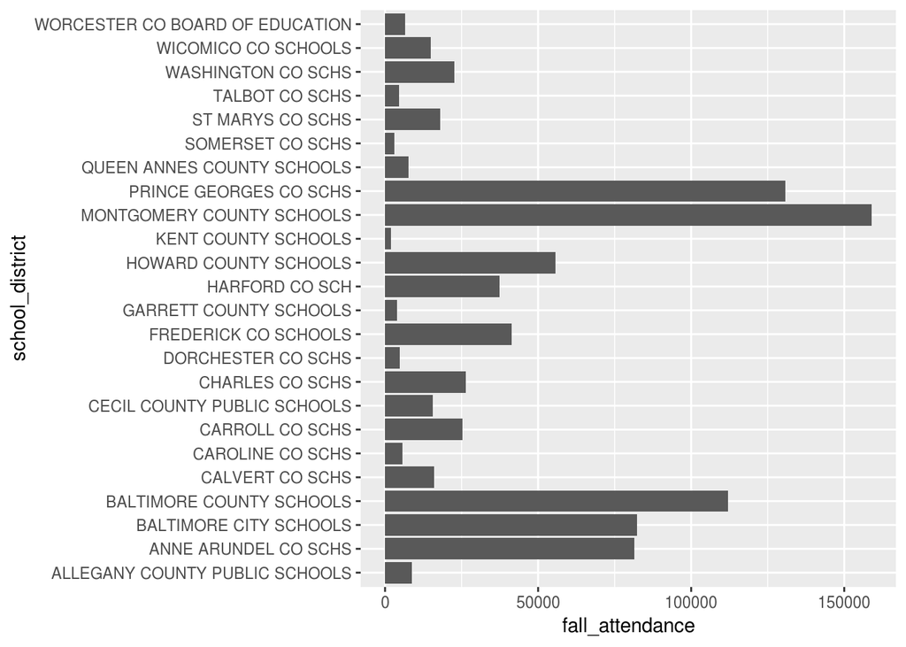

```r
ggplot(subset(school_districts, state == "Maryland"), aes(x=school_district,y=fall_attendance)) + geom_bar(stat = "identity") + coord_flip()
```

The distribution of fall attendance is pretty high, with the max attendance being over 150,000, and most being somewhere around 10,000.

Now let’s compare the attendance of a school with its total state revenue to identify any relationships:

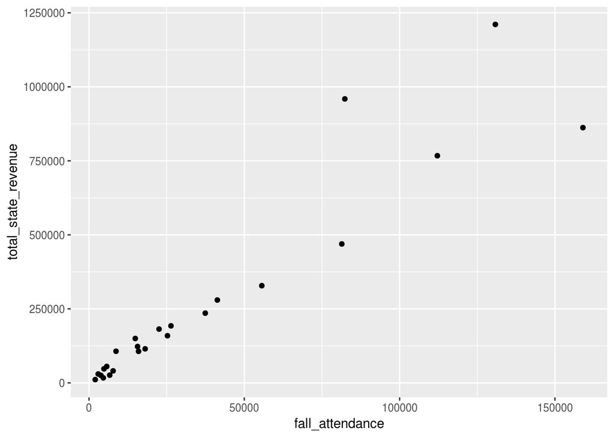

```r
ggplot(subset(state_revenue, state == "Maryland"), aes(x=fall_attendance,y=total_state_revenue)) + geom_point(stat = "identity")
```

There does seem to be a positive relationship between attendance and state revenue. It does seem justifiable for a larger school to receive more funding, Although some of the schools receive more money than those that are larger than it, possibly because of social heirarchy. Let’s compare each district’s amount of spending for school lunch, transportation, and gifted and talented programs.

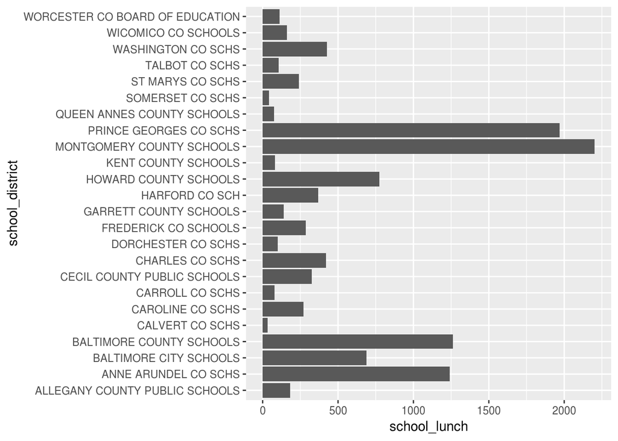

```r
ggplot(subset(state_revenue, state == "Maryland"), aes(x=school_district,y=school_lunch)) + geom_bar(stat = "identity") + coord_flip()
```

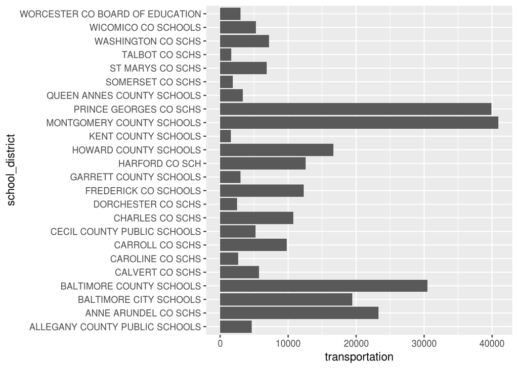

```r
ggplot(subset(state_revenue, state == "Maryland"), aes(x=school_district,y=transportation)) + geom_bar(stat = "identity") + coord_flip()
```

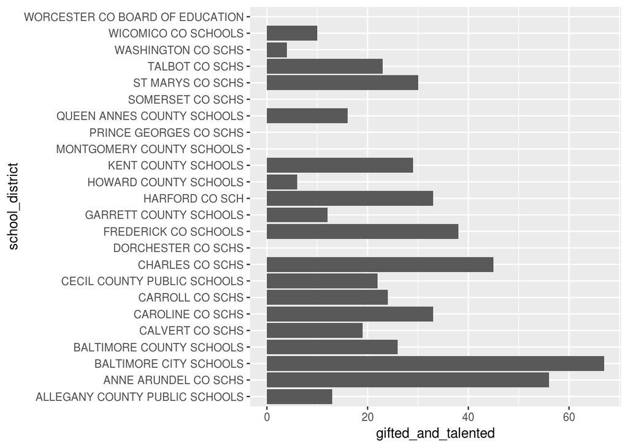

```r
ggplot(subset(state_revenue, state == "Maryland"), aes(x=school_district,y=gifted_and_talented)) + geom_bar(stat = "identity") + coord_flip()
```

Each school district receives different amounts for the various revenue types. While every district had some amount for school lunch or transportation, not all of them had funding for gifted and talented programs. I’m curious of there is something about the districts with no gifted programs and their average test scores compared to schools with more funding in that program.

## Conclusion

In this report I displayed my progress while I took a data source and cleaned up the data, and did some visualization to analyze it. There a lot of things this could be used for, such as determining what states have better school funding, and how they dispere that funding. If I were to get some more data, I could start to discover how the money a district receives affects its performance.